# Queries

The reviewers also had some requests regarding further analyses they would like included (see below for details), and some questions that I need to seek your clarification on:

**1. “what software and version was used to conduct themeta-analysis?” - I presume this was R but am aware I never actually asked.**

2. “is it not customary to conduct analyses to take out one study at a time to identify if any one study was highly influential? please provide this information” - was this the case with the prior analysis, and if so what impact / if any was there? If not, can we do this?

**3. “it would be helpful to see a funnel plot and eggers test to examine publication bias” - I am unsure how to run/conduct same, could you assist here (please let me know if you require further information).**

**4. “It would be most helpful to see forest plots for severity and preventability using random effects model”**

**5. Questioning regarding impact of hospital setting on ADR proportions**

I have attached a new Excel file for your attention. Each tab contains the data for each analysis.

**1. Overall pooled ADR proportions for all included studies**

**2. Subgroup analysis for studies where all participants were >65years - forest plot for this group and query any statistical significance between this group and overall pooled proportion (analysis #1).**

**3. Subgroup analysis for grouped ADR definitions - forest plot for each grouping and query and staistical significance between each group and overall pooled proportion(analysis #1).**

**4. Subgroup analysis for grouped ADR causality tools - forest plot for each grouping and query and staistical significance between each group and overall pooled proportion (analysis #1).**

**5. Subgroup analysis grouped by overlapping ADR methodology - forest plot for each grouping and query and staistical significance between each group and overall pooled proportion (analysis #1).**

**6. New subgroup analysis - grouped by ADR identification method - forest plot for each grouping and query any statistical significance between each group and overall pooled proportion (analysis #1).**

**7. New subgroup analysis - pooled proportions for ADR preventability based on studies reporting preventability**

**8. New subgroup analysis - pooled proportions for ADR severity based on studies reporting severity**

**9. New subgroup analysis - based on reviewer comment querying impact on risk of bias - forest plot for high quality studies and query any statistical significance between each group and overall pooled proportion (analysis #1).**

**10. New subgroup analysis - based on reviewer comment querying impact of NOS domain “demonstration that outcome of interest was not present at start of study” - forest plots for groupings that did and did not demonstarte this and query any statistical significance between each grouping and overall pooled proportion (analysis #1).**

**11. New subgroup analysis - based on reviewer comment querying impact of ward setting on ADR proportions - forest plots for each ward grouping and query any statistical significance between each grouping and overall pooled proportion (analysis #1).**

# ADRs

## Overall model

*1. “what software and version was used to conduct themeta-analysis?” - I presume this was R but am aware I never actually asked.*

All analysis were conducted using the R Language for Statistical Programming (REF1).

REF1: R Core Team (2020). R: A language and environment for statistical computing. R Foundation for Statistical Computing, Vienna, Austria. URL https://www.R-project.org/.

Meta-analysis models and plots were produced using the metafor package (REF2).

REF2: Viechtbauer, W. (2010). Conducting meta-analyses in R with the metafor package. Journal of Statistical Software, 36(3), 1-48. URL: https://www.jstatsoft.org/v36/i03/

For meta-analysis models we used a generalized linear mixed effects model for logit transformed proportions (i.e. metafor::rms.glmm(measure = “PLO”)).

*1. Overall pooled ADR proportions for all included studies except Liao*

Binomial-normal random effects model (coefficients on the log-odds scale).

```
##
## Random-Effects Model (k = 26; tau^2 estimator: ML)
##
## tau^2 (estimated amount of total heterogeneity): 0.8585
## tau (square root of estimated tau^2 value):      0.9266
## I^2 (total heterogeneity / total variability):   98.4160%
## H^2 (total variability / sampling variability):  63.1312
##
## Tests for Heterogeneity:
## Wld(df = 25) = 1277.8768, p-val < .0001
## LRT(df = 25) = 1498.3058, p-val < .0001
##
## Model Results:
##
## estimate      se     zval    pval    ci.lb    ci.ub
##  -1.6592  0.1861  -8.9138  <.0001  -2.0241  -1.2944  ***
##
## ---
## Signif. codes:  0 '***' 0.001 '**' 0.01 '*' 0.05 '.' 0.1 ' ' 1
```

Results on the probability scale. This is the mean ADR proportion, the 95% CI of that estimate, and a 95% prediction interval (the very wide interval)

```
##
##    pred  ci.lb  ci.ub  cr.lb  cr.ub
##  0.1599 0.1167 0.2151 0.0290 0.5481
```

Figure 1.

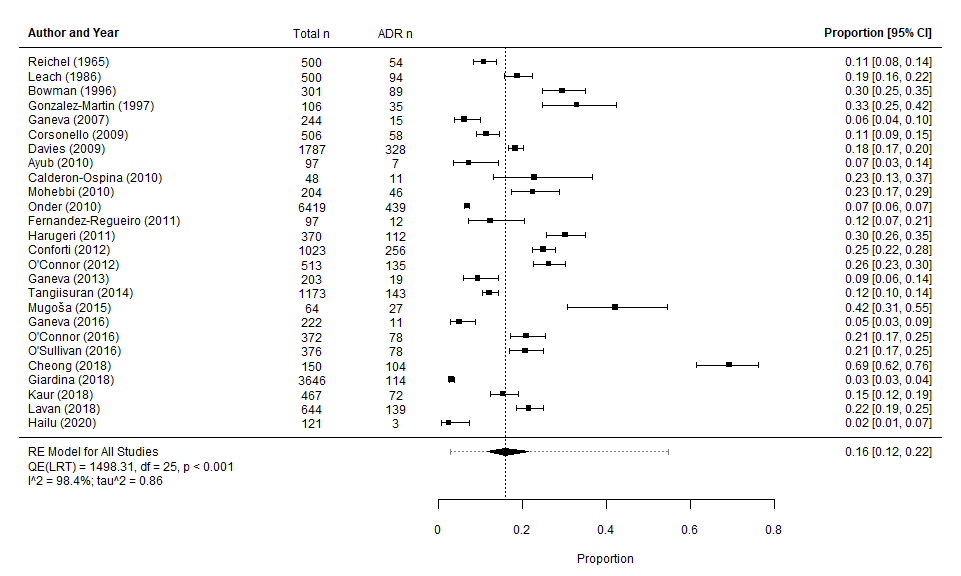

Binomial-normal random effects model, with Liao (coefficients on the log-odds scale).

```
##
## Random-Effects Model (k = 27; tau^2 estimator: ML)
##
## tau^2 (estimated amount of total heterogeneity): 1.2838
## tau (square root of estimated tau^2 value):      1.1331
## I^2 (total heterogeneity / total variability):   99.1469%
## H^2 (total variability / sampling variability):  117.2263
##
## Tests for Heterogeneity:
## Wld(df = 26) = 6854.9243, p-val < .0001
## LRT(df = 26) = 7904.2253, p-val < .0001
##
## Model Results:
##
## estimate      se     zval    pval    ci.lb    ci.ub
##  -1.7965  0.2216  -8.1053  <.0001  -2.2310  -1.3621  ***
##
## ---
## Signif. codes:  0 '***' 0.001 '**' 0.01 '*' 0.05 '.' 0.1 ' ' 1
```

```
##
##    pred  ci.lb  ci.ub  cr.lb  cr.ub
##  0.1423 0.0970 0.2039 0.0170 0.6145
```

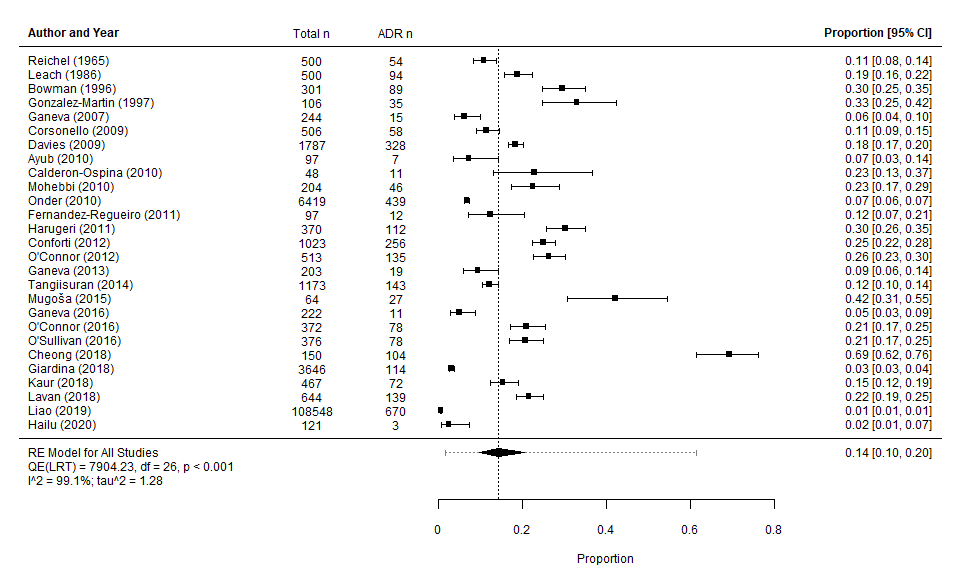

Binomial-normal fixed effects model, with Liao (coefficients on the log-odds scale).

```
##
## Fixed-Effects Model (k = 27)
##
## Tests for Heterogeneity:
## Wld(df = 26) = 6854.9243, p-val < .0001
## LRT(df = 26) = 7904.2253, p-val < .0001
##
## Model Results:
##
## estimate      se       zval    pval    ci.lb    ci.ub
##  -3.6856  0.0180  -204.2772  <.0001  -3.7210  -3.6503  ***
##
## ---
## Signif. codes:  0 '***' 0.001 '**' 0.01 '*' 0.05 '.' 0.1 ' ' 1
```

```
##
##    pred  ci.lb  ci.ub
##  0.0245 0.0236 0.0253
```

## Funnel plot

*3. “it would be helpful to see a funnel plot and eggers test to examine publication bias” - I am unsure how to run/conduct same, could you assist here (please let me know if you require further information).*

### Without Liao

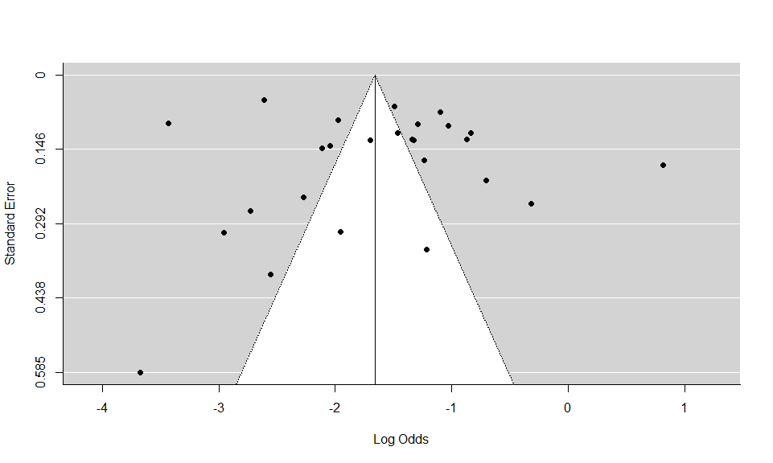

### With Liao

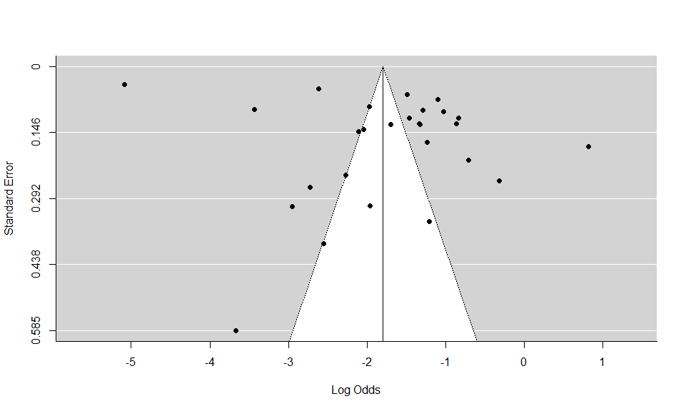

## Influence

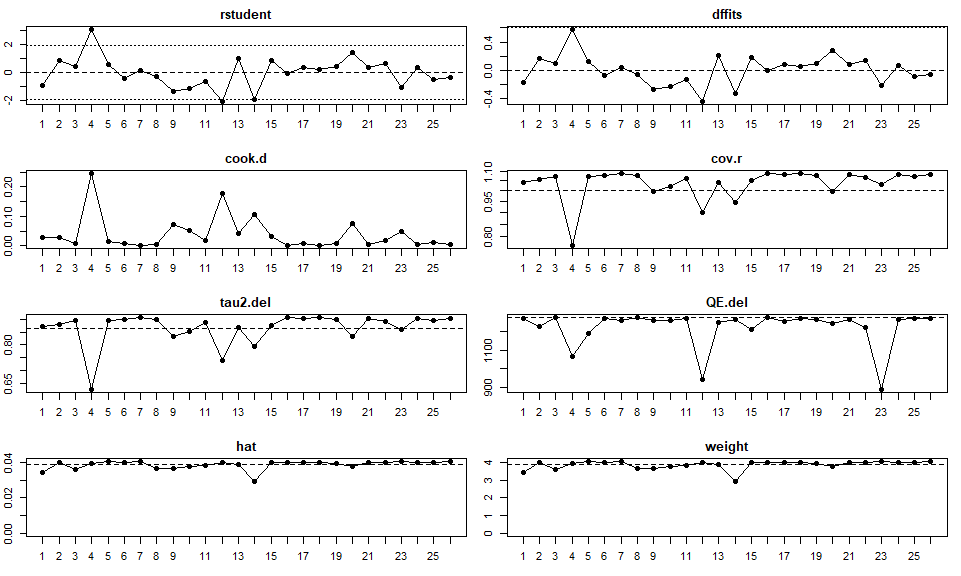

4 = Cheong (2018) 12 = Giardina (2018) 23 = Onder (2010)

```
##
##    estimate    zval  pval ci.lb ci.ub        Q    Qp  tau2     I2     H2
## 1     0.167  -8.438 0.000 0.121 0.225 1273.542 0.000 0.870 98.492 66.309
## 2     0.158  -8.708 0.000 0.114 0.215 1228.850 0.000 0.879 98.457 64.821
## 3     0.160  -8.566 0.000 0.115 0.218 1275.527 0.000 0.896 98.534 68.194
## 4     0.150 -10.596 0.000 0.113 0.196 1066.445 0.000 0.627 97.887 47.335
## 5     0.159  -8.594 0.000 0.114 0.217 1190.604 0.000 0.893 98.367 61.234
## 6     0.164  -8.374 0.000 0.118 0.223 1272.939 0.000 0.898 98.499 66.627
## 7     0.161  -8.452 0.000 0.116 0.220 1259.183 0.000 0.906 98.325 59.702
## 8     0.164  -8.407 0.000 0.118 0.223 1277.368 0.000 0.899 98.536 68.311
## 9     0.169  -8.516 0.000 0.124 0.227 1262.344 0.000 0.831 98.420 63.273
## 10    0.168  -8.455 0.000 0.122 0.226 1264.054 0.000 0.852 98.454 64.682
## 11    0.165  -8.389 0.000 0.120 0.224 1272.956 0.000 0.886 98.510 67.111
## 12    0.173  -8.813 0.000 0.129 0.229  941.909 0.000 0.742 98.126 53.372
## 13    0.157  -8.796 0.000 0.114 0.213 1252.662 0.000 0.867 98.472 65.466
## 14    0.171  -8.686 0.000 0.126 0.227 1266.920 0.000 0.793 98.352 60.671
## 15    0.158  -8.727 0.000 0.114 0.214 1211.473 0.000 0.876 98.439 64.058
## 16    0.162  -8.409 0.000 0.117 0.221 1277.795 0.000 0.906 98.504 66.863
## 17    0.160  -8.517 0.000 0.115 0.218 1254.712 0.000 0.901 98.454 64.692
## 18    0.161  -8.463 0.000 0.116 0.219 1271.864 0.000 0.905 98.490 66.208
## 19    0.160  -8.541 0.000 0.115 0.218 1268.650 0.000 0.899 98.515 67.322
## 20    0.155  -9.055 0.000 0.113 0.210 1246.010 0.000 0.831 98.414 63.044
## 21    0.160  -8.506 0.000 0.115 0.218 1267.109 0.000 0.902 98.497 66.549
## 22    0.159  -8.625 0.000 0.114 0.216 1225.292 0.000 0.889 98.443 64.206
## 23    0.168  -8.421 0.000 0.122 0.226  885.258 0.000 0.858 98.119 53.160
## 24    0.160  -8.501 0.000 0.115 0.219 1267.775 0.000 0.903 98.498 66.570
## 25    0.165  -8.373 0.000 0.119 0.224 1271.008 0.000 0.895 98.497 66.535
## 26    0.164  -8.373 0.000 0.118 0.223 1270.401 0.000 0.901 98.439 64.045
```

## Moderators

### Age

*2. Subgroup analysis for studies where all participants were >65years - forest plot for this group and query any statistical significance between this group and overall pooled proportion (analysis #1).*

Studies that only recruited those aged 65+ vs those that recruited other ages too.

| cat | n_studies | ADR_proportion | ci.lb | ci.ub | cr.lb | cr.ub | moderator_p |
| --- | --- | --- | --- | --- | --- | --- | --- |
| All ages | 14 | 0.14 | 0.09 | 0.21 | 0.02 | 0.5 | NA |
| 65+ only | 12 | 0.19 | 0.12 | 0.28 | 0.04 | 0.6 | 0.299 |

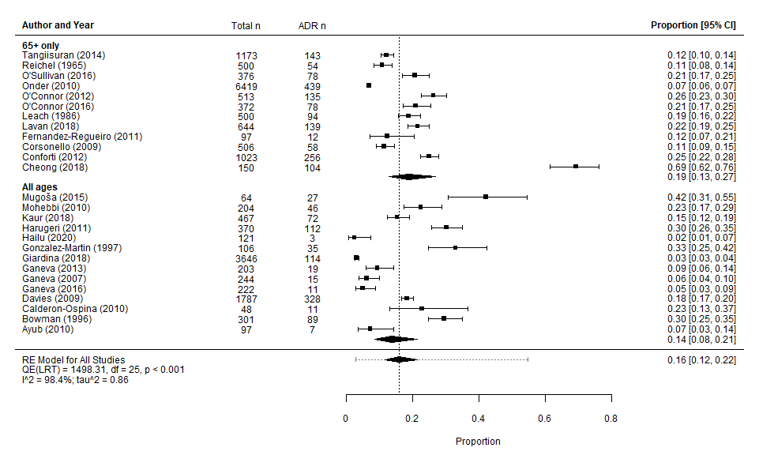

### ADR definition

*3. Subgroup analysis for grouped ADR definitions - forest plot for each grouping and query and staistical significance between each group and overall pooled proportion(analysis #1).*

| cat | n_studies | ADR_proportion | ci.lb | ci.ub | cr.lb | cr.ub | moderator_p |
| --- | --- | --- | --- | --- | --- | --- | --- |
| WHO | 15 | 0.14 | 0.09 | 0.20 | 0.03 | 0.49 | NA |
| Not documented | 3 | 0.23 | 0.10 | 0.45 | 0.04 | 0.69 | NA |
| Local policy | 1 | 0.30 | 0.07 | 0.71 | 0.03 | 0.83 | NA |
| Edwards and Aronson | 4 | 0.17 | 0.08 | 0.33 | 0.03 | 0.59 | NA |
| Bates | 1 | 0.12 | 0.02 | 0.46 | 0.01 | 0.63 | NA |
| Author defined | 2 | 0.19 | 0.06 | 0.46 | 0.03 | 0.67 | 0.806 |

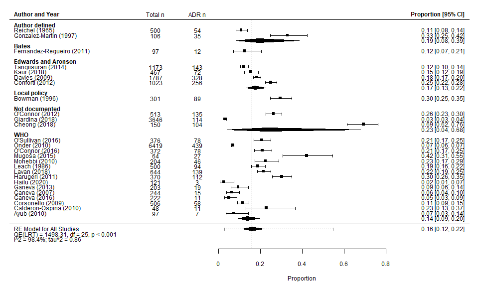

### Causality

*4. Subgroup analysis for grouped ADR causality tools - forest plot for each grouping and query and staistical significance between each group and overall pooled proportion (analysis #1).*

| cat | n_studies | ADR_proportion | ci.lb | ci.ub | cr.lb | cr.ub | moderator_p |
| --- | --- | --- | --- | --- | --- | --- | --- |
| WHO-UMC | 6 | 0.22 | 0.12 | 0.37 | 0.04 | 0.66 | NA |
| Not documented | 3 | 0.15 | 0.06 | 0.33 | 0.02 | 0.57 | NA |
| Naranjo | 15 | 0.14 | 0.09 | 0.21 | 0.03 | 0.51 | NA |
| Kramer | 1 | 0.19 | 0.04 | 0.58 | 0.02 | 0.74 | NA |
| Hallas | 1 | 0.12 | 0.02 | 0.45 | 0.01 | 0.63 | 0.78 |

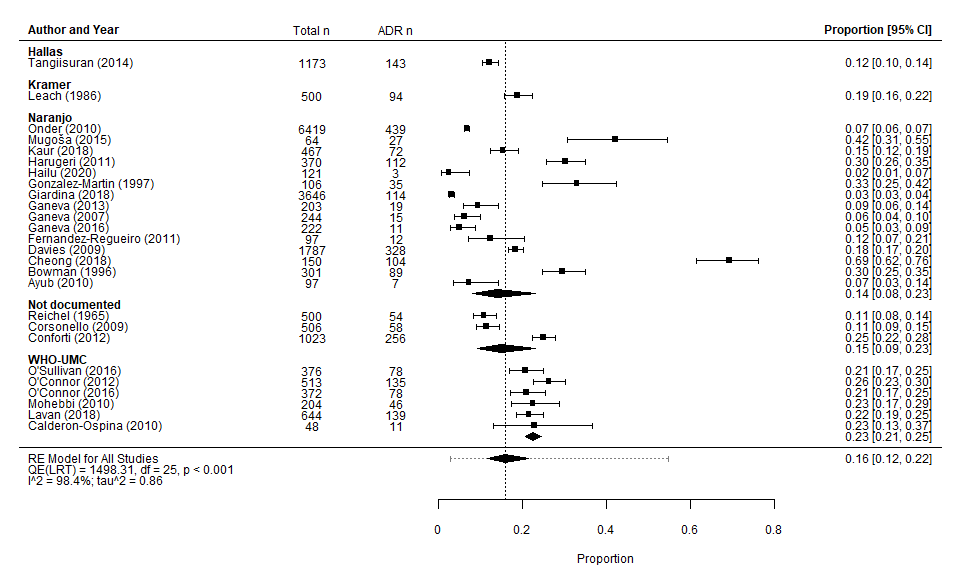

### Overlapping methods

*5. Subgroup analysis grouped by overlapping ADR methodology - forest plot for each grouping and query and staistical significance between each group and overall pooled proportion (analysis #1).*

| cat | n_studies | ADR_proportion | ci.lb | ci.ub | cr.lb | cr.ub | moderator_p |
| --- | --- | --- | --- | --- | --- | --- | --- |
| WHO & WHO-UMC | 5 | 0.22 | 0.10 | 0.40 | 0.03 | 0.70 | NA |
| WHO & Naranjo | 8 | 0.10 | 0.05 | 0.18 | 0.01 | 0.47 | NA |
| Edwards Aronson & Naranjo | 2 | 0.17 | 0.05 | 0.45 | 0.02 | 0.69 | NA |
| Not documented & Naranjo | 2 | 0.21 | 0.06 | 0.52 | 0.02 | 0.75 | 0.383 |

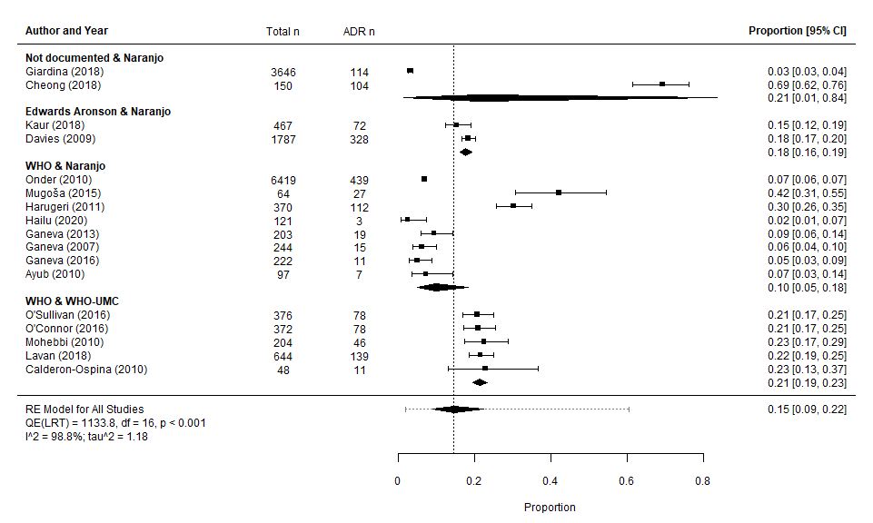

### ADR identified by

*6. New subgroup analysis - grouped by ADR identification method - forest plot for each grouping and query any statistical significance between each group and overall pooled proportion (analysis #1).*

| cat | n_studies | ADR_proportion | ci.lb | ci.ub | cr.lb | cr.ub | moderator_p |
| --- | --- | --- | --- | --- | --- | --- | --- |
| Pharmacist | 10 | 0.15 | 0.09 | 0.23 | 0.03 | 0.50 | NA |
| Physican | 7 | 0.16 | 0.09 | 0.26 | 0.03 | 0.54 | NA |
| Not documented | 5 | 0.26 | 0.14 | 0.44 | 0.05 | 0.70 | NA |
| Multi-disciplinary | 4 | 0.11 | 0.05 | 0.23 | 0.02 | 0.45 | 0.31 |

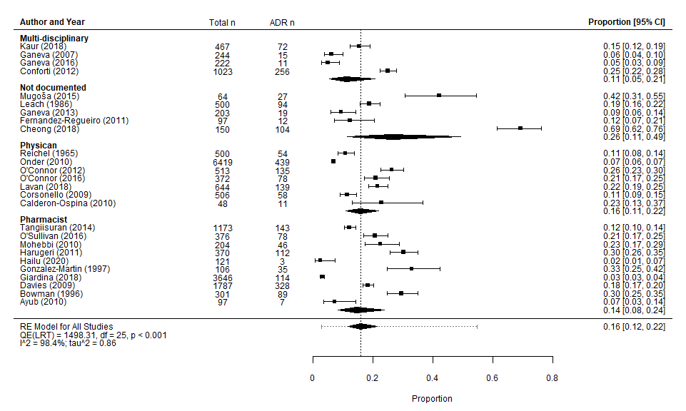

### Quality (RoB)

*9. New subgroup analysis - based on reviewer comment querying impact on risk of bias - forest plot for high quality studies and query any statistical significance between each group and overall pooled proportion (analysis #1).*

| cat | n_studies | ADR_proportion | ci.lb | ci.ub | cr.lb | cr.ub | moderator_p |
| --- | --- | --- | --- | --- | --- | --- | --- |
| Low | 15 | 0.11 | 0.08 | 0.16 | 0.02 | 0.40 | NA |
| High | 9 | 0.26 | 0.17 | 0.38 | 0.06 | 0.66 | 0.003 |

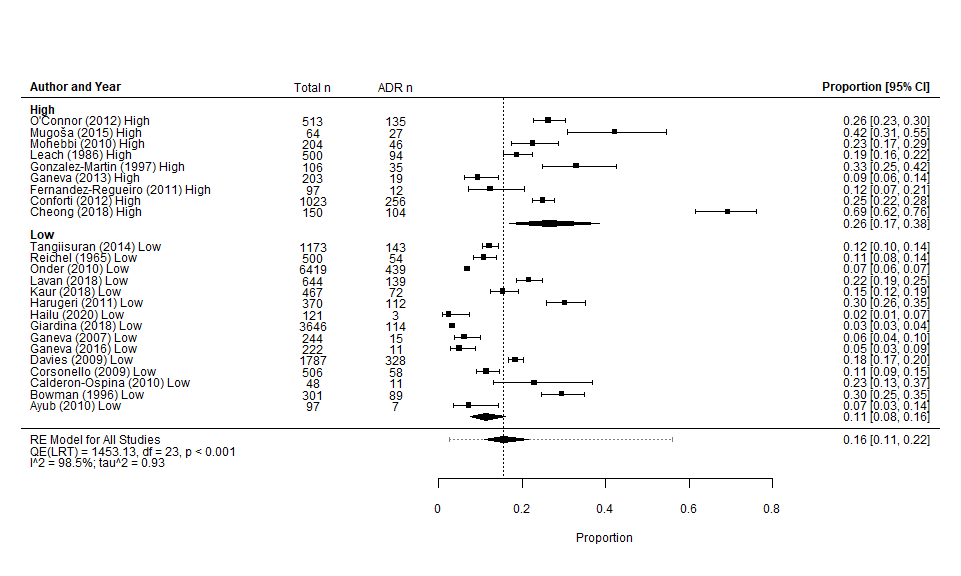

### Incident

*10. New subgroup analysis - based on reviewer comment querying impact of NOS domain “demonstration that outcome of interest was not present at start of study” - forest plots for groupings that did and did not demonstarte this and query any statistical significance between each grouping and overall pooled proportion (analysis #1).*

| cat | n_studies | ADR_proportion | ci.lb | ci.ub | cr.lb | cr.ub | moderator_p |
| --- | --- | --- | --- | --- | --- | --- | --- |
| Not clearly incident | 11 | 0.22 | 0.14 | 0.32 | 0.04 | 0.63 | NA |
| Clearly incident | 13 | 0.12 | 0.08 | 0.18 | 0.02 | 0.45 | 0.052 |

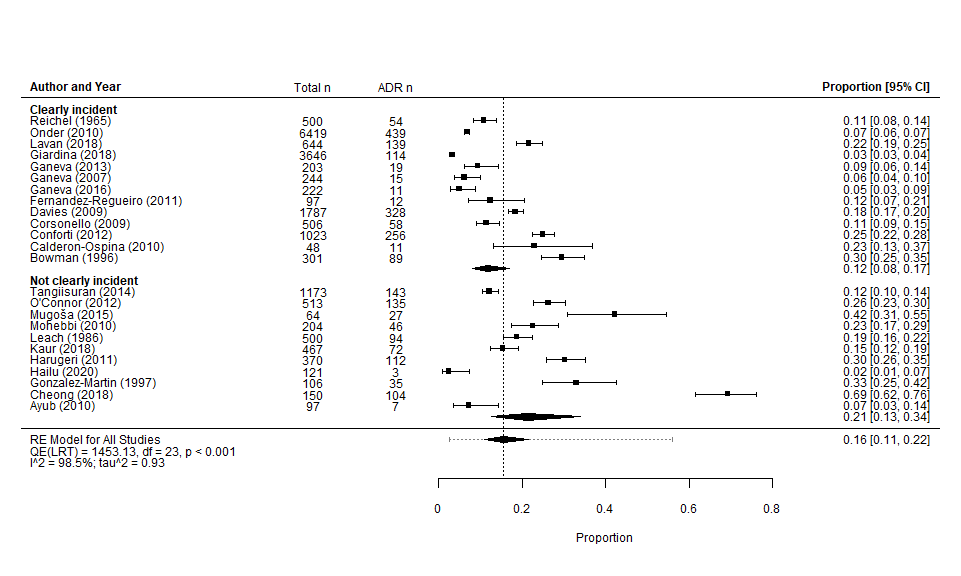

### Setting

*11. New subgroup analysis - based on reviewer comment querying impact of ward setting on ADR proportions - forest plots for each ward grouping and query any statistical significance between each grouping and overall pooled proportion (analysis #1).*

*5. Questioning regarding impact of hospital setting on ADR proportions*

| cat | n_studies | ADR_proportion | ci.lb | ci.ub | cr.lb | cr.ub | moderator_p |
| --- | --- | --- | --- | --- | --- | --- | --- |
| Cardiology | 2 | 0.31 | 0.13 | 0.57 | 0.07 | 0.74 | NA |
| Dermatology | 3 | 0.06 | 0.03 | 0.15 | 0.01 | 0.28 | NA |
| Geriatric | 5 | 0.25 | 0.15 | 0.39 | 0.06 | 0.63 | NA |
| GIM | 4 | 0.20 | 0.10 | 0.35 | 0.05 | 0.57 | NA |
| ICU | 1 | 0.07 | 0.01 | 0.28 | 0.01 | 0.41 | NA |
| Mixed | 8 | 0.15 | 0.09 | 0.23 | 0.04 | 0.46 | NA |
| Not described | 3 | 0.12 | 0.05 | 0.24 | 0.02 | 0.42 | 0.051 |

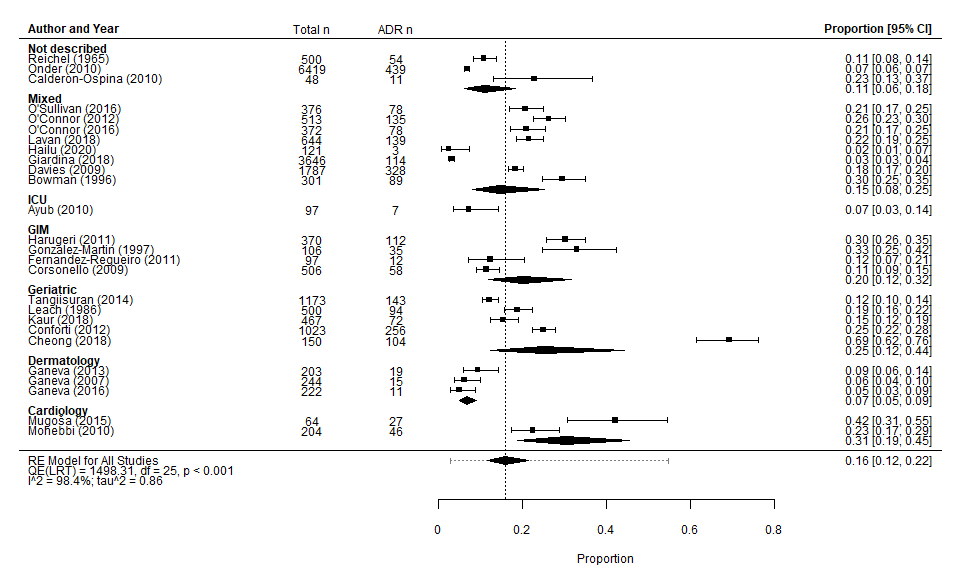

### Meta-regression with incident, quality, and setting.

```
##
## Mixed-Effects Model (k = 24; tau^2 estimator: ML)
##
## tau^2 (estimated amount of residual heterogeneity):     0.4951
## tau (square root of estimated tau^2 value):             0.7036
## I^2 (residual heterogeneity / unaccounted variability): 96.6429%
## H^2 (unaccounted variability / sampling variability):   29.7878
##
## Tests for Residual Heterogeneity:
## Wld(df = 15) = 631.2378, p-val < .0001
## LRT(df = 15) = 768.1940, p-val < .0001
##
## Test of Moderators (coefficients 2:9):
## QM(df = 8) = 18.9709, p-val = 0.0150
##
## Model Results:
##
##                           estimate      se     zval    pval    ci.lb    ci.ub
## intrcpt                    -1.5648  0.6433  -2.4324  0.0150  -2.8257  -0.3039
## settingDermatology         -1.1907  0.8222  -1.4481  0.1476  -2.8023   0.4209
## settingGeriatric            0.0429  0.6327   0.0678  0.9460  -1.1973   1.2830
## settingGIM                 -0.0960  0.6909  -0.1390  0.8895  -1.4501   1.2580
## settingICU                 -1.0406  1.0340  -1.0063  0.3143  -3.0672   0.9861
## settingMixed               -0.3216  0.7242  -0.4441  0.6569  -1.7409   1.0977
## settingNot described       -0.2977  0.8585  -0.3468  0.7287  -1.9803   1.3848
## qualityHigh                 0.7664  0.3785   2.0249  0.0429   0.0246   1.5083
## incidentClearly incident   -0.1801  0.4157  -0.4331  0.6649  -0.9949   0.6348
##
## intrcpt                   *
## settingDermatology
## settingGeriatric
## settingGIM
## settingICU
## settingMixed
## settingNot described
## qualityHigh               *
## incidentClearly incident
##
## ---
## Signif. codes:  0 '***' 0.001 '**' 0.01 '*' 0.05 '.' 0.1 ' ' 1
```

# Severity

*4. “It would be most helpful to see forest plots for severity and preventability using random effects model”*

*8. New subgroup analysis - pooled proportions for ADR severity based on studies reporting severity*

# Overall model

Binomial-normal random effects model (coefficients on the log-odds scale).

```
##
## Random-Effects Model (k = 13; tau^2 estimator: ML)
##
## tau^2 (estimated amount of total heterogeneity): 0.6846
## tau (square root of estimated tau^2 value):      0.8274
## I^2 (total heterogeneity / total variability):   94.8465%
## H^2 (total variability / sampling variability):  19.4044
##
## Tests for Heterogeneity:
## Wld(df = 12) = 219.5195, p-val < .0001
## LRT(df = 12) = 258.2922, p-val < .0001
##
## Model Results:
##
## estimate      se    zval    pval   ci.lb   ci.ub
##   0.5613  0.2446  2.2946  0.0218  0.0819  1.0407  *
##
## ---
## Signif. codes:  0 '***' 0.001 '**' 0.01 '*' 0.05 '.' 0.1 ' ' 1
```

```
##
##    pred  ci.lb  ci.ub  cr.lb  cr.ub
##  0.6367 0.5205 0.7390 0.2442 0.9048
```

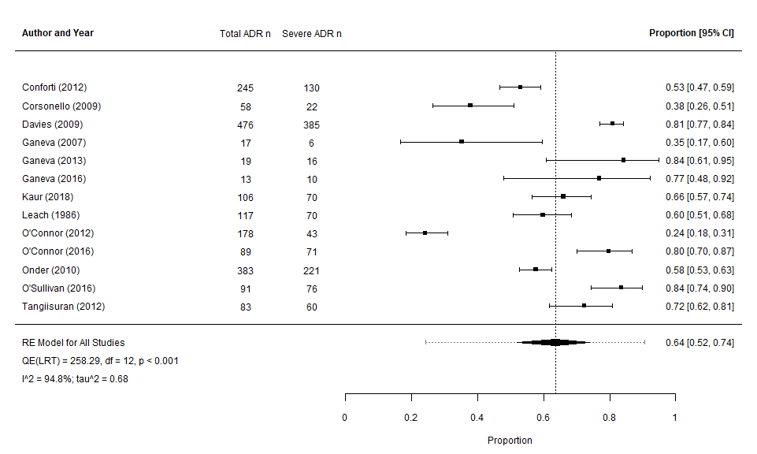

## Moderators

### Age

```
##
## Mixed-Effects Model (k = 13; tau^2 estimator: ML)
##
## tau^2 (estimated amount of residual heterogeneity):     0.6222
## tau (square root of estimated tau^2 value):             0.7888
## I^2 (residual heterogeneity / unaccounted variability): 93.7735%
## H^2 (unaccounted variability / sampling variability):   16.0604
##
## Tests for Residual Heterogeneity:
## Wld(df = 11) = 147.0018, p-val < .0001
## LRT(df = 11) = 172.0117, p-val < .0001
##
## Test of Moderators (coefficient 2):
## QM(df = 1) = 1.0727, p-val = 0.3003
##
## Model Results:
##
##          estimate      se     zval    pval    ci.lb   ci.ub
## intrcpt    1.4079  0.8527   1.6511  0.0987  -0.2633  3.0792  .
## mods      -0.5120  0.4943  -1.0357  0.3003  -1.4808  0.4569
##
## ---
## Signif. codes:  0 '***' 0.001 '**' 0.01 '*' 0.05 '.' 0.1 ' ' 1
```

| cat | n_studies | Severity_proportion | ci.lb | ci.ub | cr.lb | cr.ub | moderator_p |
| --- | --- | --- | --- | --- | --- | --- | --- |
| All ages | 5 | 0.71 | 0.53 | 0.84 | 0.30 | 0.93 | NA |
| 65+ only | 8 | 0.59 | 0.45 | 0.72 | 0.22 | 0.88 | 0.3 |

### Tool

```
##
## Mixed-Effects Model (k = 13; tau^2 estimator: ML)
##
## tau^2 (estimated amount of residual heterogeneity):     0.6717
## tau (square root of estimated tau^2 value):             0.8196
## I^2 (residual heterogeneity / unaccounted variability): 94.1938%
## H^2 (unaccounted variability / sampling variability):   17.2230
##
## Tests for Residual Heterogeneity:
## Wld(df = 11) = 216.7034, p-val < .0001
## LRT(df = 11) = 251.3082, p-val < .0001
##
## Test of Moderators (coefficient 2):
## QM(df = 1) = 0.4541, p-val = 0.5004
##
## Model Results:
##
##          estimate      se    zval    pval    ci.lb   ci.ub
## intrcpt    0.2670  0.4982  0.5360  0.5920  -0.7095  1.2435
## mods       0.1020  0.1514  0.6739  0.5004  -0.1947  0.3987
##
## ---
## Signif. codes:  0 '***' 0.001 '**' 0.01 '*' 0.05 '.' 0.1 ' ' 1
```

| cat | n_studies | Severity_proportion | ci.lb | ci.ub | cr.lb | cr.ub | moderator_p |
| --- | --- | --- | --- | --- | --- | --- | --- |
| Author defined | 4 | 0.59 | 0.41 | 0.75 | 0.20 | 0.89 | NA |
| Hallas | 1 | 0.62 | 0.48 | 0.73 | 0.23 | 0.90 | NA |
| Hartwig Scale | 4 | 0.64 | 0.52 | 0.74 | 0.25 | 0.90 | NA |
| Hurwitz | 1 | 0.66 | 0.52 | 0.78 | 0.26 | 0.92 | NA |
| Not described | 2 | 0.69 | 0.50 | 0.83 | 0.27 | 0.93 | NA |
| Self described clinical judgement | 1 | 0.71 | 0.46 | 0.87 | 0.26 | 0.94 | 0.5 |

# Preventability

*4. “It would be most helpful to see forest plots for severity and preventability using random effects model”*

*7. New subgroup analysis - pooled proportions for ADR preventability based on studies reporting preventability*

# Overall model

Binomial-normal random effects model (coefficients on the log-odds scale).

```
##
## Random-Effects Model (k = 4; tau^2 estimator: ML)
##
## tau^2 (estimated amount of total heterogeneity): 1.4012
## tau (square root of estimated tau^2 value):      1.1837
## I^2 (total heterogeneity / total variability):   95.5560%
## H^2 (total variability / sampling variability):  22.5022
##
## Tests for Heterogeneity:
## Wld(df = 3) = 32.1567, p-val < .0001
## LRT(df = 3) = 70.2180, p-val < .0001
##
## Model Results:
##
## estimate      se    zval    pval    ci.lb   ci.ub
##   0.9302  0.6258  1.4865  0.1372  -0.2963  2.1567
##
## ---
## Signif. codes:  0 '***' 0.001 '**' 0.01 '*' 0.05 '.' 0.1 ' ' 1
```

```
##
##    pred  ci.lb  ci.ub  cr.lb  cr.ub
##  0.7171 0.4265 0.8963 0.1552 0.9722
```

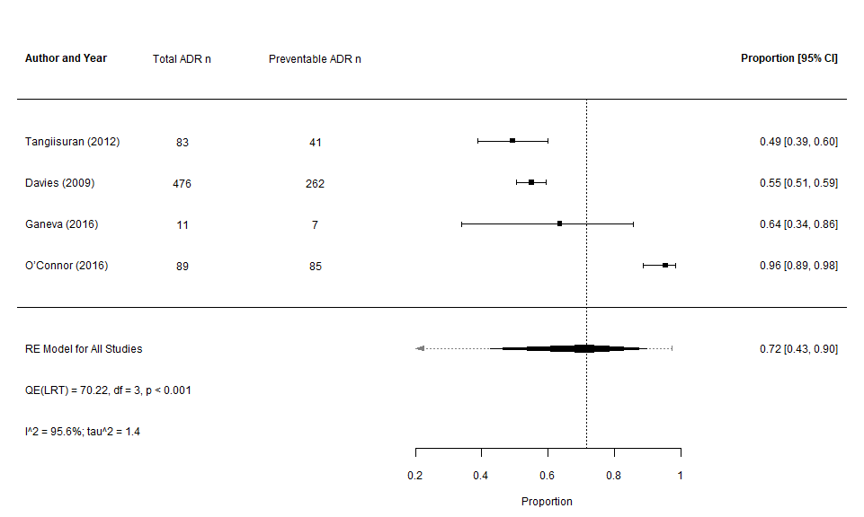

## Moderators

### Age

```
##
## Mixed-Effects Model (k = 4; tau^2 estimator: ML)
##
## tau^2 (estimated amount of residual heterogeneity):     1.1392
## tau (square root of estimated tau^2 value):             1.0673
## I^2 (residual heterogeneity / unaccounted variability): 86.6907%
## H^2 (unaccounted variability / sampling variability):   7.5135
##
## Tests for Residual Heterogeneity:
## Wld(df = 2) = 30.9321, p-val < .0001
## LRT(df = 2) = 52.4000, p-val < .0001
##
## Test of Moderators (coefficient 2):
## QM(df = 1) = 0.8855, p-val = 0.3467
##
## Model Results:
##
##          estimate      se     zval    pval    ci.lb   ci.ub
## intrcpt   -0.7003  1.8099  -0.3869  0.6988  -4.2476  2.8471
## mods       1.0715  1.1387   0.9410  0.3467  -1.1603  3.3033
##
## ---
## Signif. codes:  0 '***' 0.001 '**' 0.01 '*' 0.05 '.' 0.1 ' ' 1
```

| cat | n_studies | Preventability_proportion | ci.lb | ci.ub | cr.lb | cr.ub | moderator_p |
| --- | --- | --- | --- | --- | --- | --- | --- |
| All ages | 2 | 0.59 | 0.23 | 0.88 | 0.09 | 0.95 | NA |
| 65+ only | 2 | 0.81 | 0.47 | 0.95 | 0.24 | 0.98 | 0.347 |

# Appendices

## Codebook

Data Frame Summary

data

**Dimensions**: 26 x 22  
**Duplicates**: 0

| **No** | **Variable** | **Stats / Values** | **Freqs (% of Valid)** | **Graph** | **Valid** | **Missing** |
| --- | --- | --- | --- | --- | --- | --- |
| 1 | author [character] | 1. Ganeva 2. O'Connor 3. Ayub 4. Bowman 5. Calderon-Ospina 6. Cheong 7. Conforti 8. Corsonello 9. Davies 10. Fernandez-Regueiro [ 13 others ] | 3 ( 11.5% ) 2 ( 7.7% ) 1 ( 3.8% ) 1 ( 3.8% ) 1 ( 3.8% ) 1 ( 3.8% ) 1 ( 3.8% ) 1 ( 3.8% ) 1 ( 3.8% ) 1 ( 3.8% ) 13 ( 50.0% ) |  | 26 (100%) | 0 (0%) |
| 2 | year [numeric] | Mean (sd) : 2009.1 (11.8) min < med < max: 1965 < 2011.5 < 2020 IQR (CV) : 6.8 (0) | 15 distinct values |  | 26 (100%) | 0 (0%) |
| 3 | total_n_65 [numeric] | Mean (sd) : 775.1 (1369.9) min < med < max: 48 < 371 < 6419 IQR (CV) : 348 (1.8) | 24 distinct values |  | 26 (100%) | 0 (0%) |
| 4 | adr_n_65 [numeric] | Mean (sd) : 95.3 (103.8) min < med < max: 3 < 75 < 439 IQR (CV) : 92.5 (1.1) | 24 distinct values |  | 26 (100%) | 0 (0%) |
| 5 | no_adr_n_65 [numeric] | Mean (sd) : 679.8 (1289.9) min < med < max: 37 < 276 < 5980 IQR (CV) : 319.5 (1.9) | 25 distinct values |  | 26 (100%) | 0 (0%) |
| 6 | pct_adr_65 [numeric] | Mean (sd) : 19.4 (14.3) min < med < max: 2.5 < 18.6 < 69.3 IQR (CV) : 14.8 (0.7) | 26 distinct values |  | 26 (100%) | 0 (0%) |
| 7 | all [numeric] | 1 distinct value | 1 : 26 ( 100.0% ) |  | 26 (100%) | 0 (0%) |
| 8 | old_vs_new [factor] | 1. Previous review 2. Updated review | 25 ( 96.2% ) 1 ( 3.8% ) |  | 26 (100%) | 0 (0%) |
| 9 | all_ages_vs_65_only [factor] | 1. All ages 2. 65+ only | 14 ( 53.8% ) 12 ( 46.2% ) |  | 26 (100%) | 0 (0%) |
| 10 | adr_def [factor] | 1. WHO 2. Not documented 3. Local policy 4. Edwards and Aronson 5. Bates 6. Author defined | 15 ( 57.7% ) 3 ( 11.5% ) 1 ( 3.8% ) 4 ( 15.4% ) 1 ( 3.8% ) 2 ( 7.7% ) |  | 26 (100%) | 0 (0%) |
| 11 | causality [factor] | 1. WHO-UMC 2. Not documented 3. Naranjo 4. Kramer 5. Hallas | 6 ( 23.1% ) 3 ( 11.5% ) 15 ( 57.7% ) 1 ( 3.8% ) 1 ( 3.8% ) |  | 26 (100%) | 0 (0%) |
| 12 | overlap_methods [factor] | 1. WHO & WHO-UMC 2. WHO & Naranjo 3. Edwards Aronson & Naranjo 4. Not documented & Naranjo | 5 ( 29.4% ) 8 ( 47.1% ) 2 ( 11.8% ) 2 ( 11.8% ) |  | 17 (65.38%) | 9 (34.62%) |
| 13 | adr_id_method [factor] | 1. Pharmacist 2. Physican 3. Not documented 4. Multi-disciplinary | 10 ( 38.5% ) 7 ( 26.9% ) 5 ( 19.2% ) 4 ( 15.4% ) |  | 26 (100%) | 0 (0%) |
| 14 | quality [factor] | 1. Low 2. High | 15 ( 62.5% ) 9 ( 37.5% ) |  | 24 (92.31%) | 2 (7.69%) |
| 15 | incident [factor] | 1. Not clearly incident 2. Clearly incident | 11 ( 45.8% ) 13 ( 54.2% ) |  | 24 (92.31%) | 2 (7.69%) |
| 16 | setting [factor] | 1. Cardiology 2. Dermatology 3. Geriatric 4. GIM 5. ICU 6. Mixed 7. Not described | 2 ( 7.7% ) 3 ( 11.5% ) 5 ( 19.2% ) 4 ( 15.4% ) 1 ( 3.8% ) 8 ( 30.8% ) 3 ( 11.5% ) |  | 26 (100%) | 0 (0%) |
| 17 | id [integer] | Mean (sd) : 13.8 (8) min < med < max: 1 < 13.5 < 27 IQR (CV) : 13.5 (0.6) | 26 distinct values |  | 26 (100%) | 0 (0%) |
| 18 | study [character] | 1. Ayub (2010) 2. Bowman (1996) 3. Calderon-Ospina (2010) 4. Cheong (2018) 5. Conforti (2012) 6. Corsonello (2009) 7. Davies (2009) 8. Fernandez-Regueiro (2011) 9. Ganeva (2007) 10. Ganeva (2013) [ 16… | 1 ( 3.8% ) 1 ( 3.8% ) 1 ( 3.8% ) 1 ( 3.8% ) 1 ( 3.8% ) 1 ( 3.8% ) 1 ( 3.8% ) 1 ( 3.8% ) 1 ( 3.8% ) 1 ( 3.8% ) 16 ( 61.5% ) |  | 26 (100%) | 0 (0%) |
| 19 | yi [numeric] | Mean (sd) : 0.2 (0.1) min < med < max: 0 < 0.2 < 0.7 IQR (CV) : 0.1 (0.7) | 26 distinct values |  | 26 (100%) | 0 (0%) |
| 20 | vi [numeric] | Mean (sd) : 0 (0) min < med < max: 0 < 0 < 0 IQR (CV) : 0 (1.4) | 26 distinct values |  | 26 (100%) | 0 (0%) |
| 21 | ci.lb [numeric] | Mean (sd) : 0.2 (0.1) min < med < max: 0 < 0.1 < 0.6 IQR (CV) : 0.2 (0.8) | 26 distinct values |  | 26 (100%) | 0 (0%) |
| 22 | ci.ub [numeric] | Mean (sd) : 0.2 (0.2) min < med < max: 0 < 0.2 < 0.8 IQR (CV) : 0.2 (0.7) | 26 distinct values |  | 26 (100%) | 0 (0%) |

Generated by summarytools 0.9.6 ([R](https://www.r-project.org/) version 3.6.3)  
2020-06-01

## System info

```
##
## System: Windows 10 x64 build 18363
## Nodename: DESKTOP-JKQ7LTN, User: Darren
## Total Memory: 16168 MB
##
## R version 3.6.3 (2020-02-29)
## x86_64-w64-mingw32/x64 (64-bit)
##
## Loaded Packages:
##  flextable (0.5.10), viridis (0.5.1), viridisLite (0.3.0), metafor (2.4-0), Matrix (1.2-18), forcats (0.5.0), stringr (1.4.0), dplyr (0.8.5), purrr (0.3.4), readr (1.3.1), tidyr (1.1.0), tibble (3.0.1), ggplot2 (3.3.0), tidyverse (1.3.0)
```